# World Cities Air Pollution

### Cluster Analysis - Air pollution indicators for World cities:

The following analysis is based on an example provided in the book “Cluster Analysis 5th Edition EVERITT LANDAU LEES.”

| Country | City | so2 | dew | humidity | pressure | temperature | wind_gust | wind_speed | POP |
| --- | --- | --- | --- | --- | --- | --- | --- | --- | --- |
| AR | Buenos Aires | 3.2858491 | 11.0084906 | 70.41029 | 1015.4506 | 17.889143 | 7.9586667 | 3.4546667 | 14967 |
| AU | Adelaide | 0.7770833 | 8.1684058 | 61.84653 | 1017.0685 | 16.530925 | 9.2808219 | 4.0635135 | 1320 |
| AU | Brisbane | 1.1178082 | 14.6772989 | 67.90546 | 1017.2216 | 20.825287 | 6.6054795 | 1.9863014 | 2338 |
| AU | Melbourne | 0.7197740 | 8.8893064 | 72.44886 | 1016.4043 | 14.923714 | 8.8146667 | 3.5360000 | 4771 |
| AU | Perth | 3.2636771 | 10.7390805 | 67.26476 | 1015.2851 | 18.294269 | 10.4973333 | 5.0824324 | 1991 |
| AU | Sydney | 1.7206304 | 11.9580925 | 73.22098 | 1014.7052 | 17.867241 | 6.4410959 | 2.6000000 | 4792 |
| AU | Wollongong | 2.7522337 | 11.4120690 | 72.45546 | 1014.3595 | 16.963506 | 7.3739726 | 4.0726027 | 301 |
| BA | Sarajevo | 11.4279070 | 5.7526761 | 74.84045 | 986.1317 | 10.651966 | 11.2250000 | 1.7135802 | 343 |
| BE | Charleroi | 0.6953390 | 6.6906158 | 72.42522 | 1016.2894 | 12.065982 | 8.3333333 | 4.6196970 | 411 |
| BG | Plovdiv | 4.0824405 | 6.9558824 | 63.65337 | 1016.5265 | 14.021471 | 6.4180328 | 3.0402778 | 345 |

[output cut: 189 more lines]

In this example, we will use seven climate and human ecology variables to assess whether there is any evidence that there are groups of cities with similar profiles.

### Scatterplot Matrix

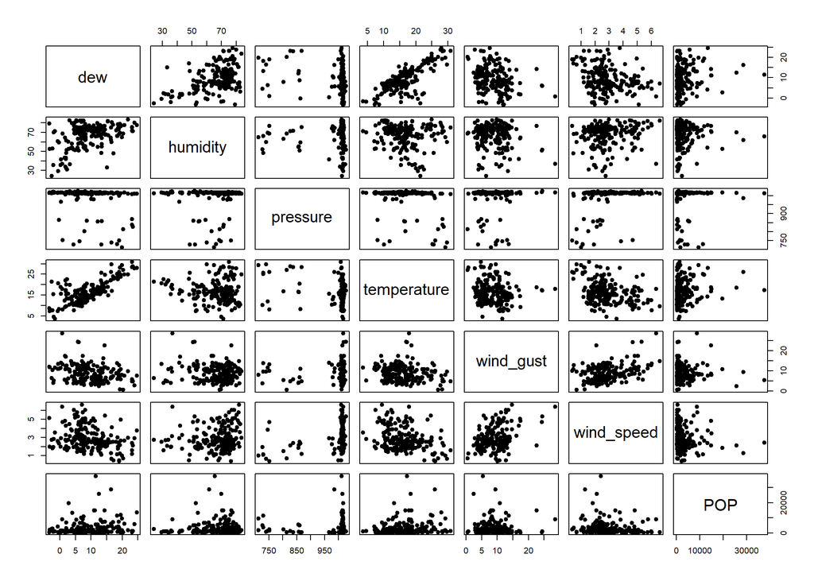

The plot does not seem to reveal any obvious separate groups. It is possible to notice the presence of some outliers.

#### Preparing the data

First, let’s normalize the data prior to running the algorithm.

| Country | City | so2 | dew_s | humidity_s | pressure_s | temperature_s | wind_gust_s | wind_speed_s | POP_s |
| --- | --- | --- | --- | --- | --- | --- | --- | --- | --- |
| AR | Buenos Aires | 3.2858491 | 0.25345026 | 0.317632136 | 0.32907908 | 0.241338556 | -0.197177209 | 0.4763513017 | 2.474122667 |
| AU | Adelaide | 0.7770833 | -0.22222223 | -0.399606943 | 0.35306532 | -0.015012045 | 0.118984918 | 0.9656257285 | -0.381319227 |
| AU | Brisbane | 1.1178082 | 0.86792177 | 0.107845742 | 0.35533440 | 0.795507625 | -0.520759895 | -0.7036393523 | -0.168317113 |
| AU | Melbourne | 0.7197740 | -0.10148197 | 0.488368370 | 0.34321819 | -0.318357600 | 0.007514926 | 0.5417114497 | 0.340753754 |
| AU | Perth | 3.2636771 | 0.20832802 | 0.054184992 | 0.32662593 | 0.317802288 | 0.409884823 | 1.7844375079 | -0.240921959 |
| AU | Sydney | 1.7206304 | 0.41249464 | 0.553035634 | 0.31802832 | 0.237204862 | -0.560068332 | -0.2104659917 | 0.345147708 |
| AU | Wollongong | 2.7522337 | 0.32104372 | 0.488921359 | 0.31290337 | 0.066633443 | -0.336992952 | 0.9729299069 | -0.594530577 |
| BA | Sarajevo | 11.4279070 | -0.62682149 | 0.688671119 | -0.10558142 | -1.124608999 | 0.583889079 | -0.9228003314 | -0.585742670 |
| BE | Charleroi | 0.6953390 | -0.46973035 | 0.486388686 | 0.34151561 | -0.857727041 | -0.107584545 | 1.4125794134 | -0.571514631 |
| BG | Plovdiv | 4.0824405 | -0.42530210 | -0.248278830 | 0.34502961 | -0.488647431 | -0.565583327 | 0.1433449190 | -0.585324198 |

[output cut: 189 more lines]